# Rose Project 2

```python
import statsmodels.api as sm

for param in pdq:
    for param_seasonal in PDQ:
        SARIMA_model = sm.tsa.statespace.SARIMAX(train['Rose'].values,
                                            order=param,
                                            seasonal_order=param_seasonal,
                                            enforce_stationarity=False,
                                            enforce_invertibility=False)

        results_SARIMA = SARIMA_model.fit(maxiter=1000)
        print('SARIMA{}x{} - AIC:{}'.format(param, param_seasonal, results_SARIMA.aic))
        SARIMA_AIC = SARIMA_AIC.append({'param':param,'seasonal':param_seasonal ,'AIC': results_SARIMA.aic}, ignore_index=True)
```

```
SARIMA(0, 1, 0)x(0, 0, 0, 6) - AIC:1323.9657875279158
SARIMA(0, 1, 0)x(0, 0, 1, 6) - AIC:1264.4996261113859
SARIMA(0, 1, 0)x(0, 0, 2, 6) - AIC:1144.7077471827401
SARIMA(0, 1, 0)x(0, 0, 3, 6) - AIC:1081.2713830625262
SARIMA(0, 1, 0)x(1, 0, 0, 6) - AIC:1274.7897737087985
SARIMA(0, 1, 0)x(1, 0, 1, 6) - AIC:1241.7870945149145
SARIMA(0, 1, 0)x(1, 0, 2, 6) - AIC:1146.309326672227
SARIMA(0, 1, 0)x(1, 0, 3, 6) - AIC:1058.9861743124347
SARIMA(0, 1, 0)x(2, 0, 0, 6) - AIC:1137.9167236212038
SARIMA(0, 1, 0)x(2, 0, 1, 6) - AIC:1137.4533629515201
SARIMA(0, 1, 0)x(2, 0, 2, 6) - AIC:1117.022442633377
SARIMA(0, 1, 0)x(2, 0, 3, 6) - AIC:1058.804820641747
SARIMA(0, 1, 0)x(3, 0, 0, 6) - AIC:1072.5465834695271
SARIMA(0, 1, 0)x(3, 0, 1, 6) - AIC:1061.3687765139516
SARIMA(0, 1, 0)x(3, 0, 2, 6) - AIC:1058.0425052390726
SARIMA(0, 1, 0)x(3, 0, 3, 6) - AIC:1058.8917099573337
SARIMA(0, 1, 1)x(0, 0, 0, 6) - AIC:1263.5369097383964
SARIMA(0, 1, 1)x(0, 0, 1, 6) - AIC:1201.383254802954
SARIMA(0, 1, 1)x(0, 0, 2, 6) - AIC:1097.1908217752782
SARIMA(0, 1, 1)x(0, 0, 3, 6) - AIC:1021.0943496440993
SARIMA(0, 1, 1)x(1, 0, 0, 6) - AIC:1222.4354735745055
SARIMA(0, 1, 1)x(1, 0, 1, 6) - AIC:1160.4386253746572
SARIMA(0, 1, 1)x(1, 0, 2, 6) - AIC:1084.8564122997861
SARIMA(0, 1, 1)x(1, 0, 3, 6) - AIC:1005.7429848618002
SARIMA(0, 1, 1)x(2, 0, 0, 6) - AIC:1095.749037998232
SARIMA(0, 1, 1)x(2, 0, 1, 6) - AIC:1097.645518826207
SARIMA(0, 1, 1)x(2, 0, 2, 6) - AIC:1053.0044082619772
SARIMA(0, 1, 1)x(2, 0, 3, 6) - AIC:965.0642493831537
SARIMA(0, 1, 1)x(3, 0, 0, 6) - AIC:1033.873915726681
SARIMA(0, 1, 1)x(3, 0, 1, 6) - AIC:1020.293719210997
SARIMA(0, 1, 1)x(3, 0, 2, 6) - AIC:1007.9773110330455
SARIMA(0, 1, 1)x(3, 0, 3, 6) - AIC:967.0624886190097
SARIMA(0, 1, 2)x(0, 0, 0, 6) - AIC:1251.667543054104
SARIMA(0, 1, 2)x(0, 0, 1, 6) - AIC:1192.001719456311
SARIMA(0, 1, 2)x(0, 0, 2, 6) - AIC:1081.8324069561704
SARIMA(0, 1, 2)x(0, 0, 3, 6) - AIC:1004.1787326539682
SARIMA(0, 1, 2)x(1, 0, 0, 6) - AIC:1222.0132244495626
SARIMA(0, 1, 2)x(1, 0, 1, 6) - AIC:1153.851934820729
SARIMA(0, 1, 2)x(1, 0, 2, 6) - AIC:1061.4359846052305
SARIMA(0, 1, 2)x(1, 0, 3, 6) - AIC:998.7289439241581
```

[output cut: 201 more lines]

```
SARIMA(3, 1, 3)x(0, 0, 1, 6) - AIC:1176.1392426547875
SARIMA(3, 1, 3)x(0, 0, 2, 6) - AIC:1057.3381153377575
SARIMA(3, 1, 3)x(0, 0, 3, 6) - AIC:994.1518973259856
SARIMA(3, 1, 3)x(1, 0, 0, 6) - AIC:1179.1465431631066
SARIMA(3, 1, 3)x(1, 0, 1, 6) - AIC:1126.6260872762282
SARIMA(3, 1, 3)x(1, 0, 2, 6) - AIC:1057.3117926742814
SARIMA(3, 1, 3)x(1, 0, 3, 6) - AIC:982.6952103416507
SARIMA(3, 1, 3)x(2, 0, 0, 6) - AIC:1044.9852581507803
SARIMA(3, 1, 3)x(2, 0, 1, 6) - AIC:1054.3672228819914
SARIMA(3, 1, 3)x(2, 0, 2, 6) - AIC:1037.752443855646
SARIMA(3, 1, 3)x(2, 0, 3, 6) - AIC:952.5821008675782
SARIMA(3, 1, 3)x(3, 0, 0, 6) - AIC:964.8364659349224
SARIMA(3, 1, 3)x(3, 0, 1, 6) - AIC:966.4949686387279
SARIMA(3, 1, 3)x(3, 0, 2, 6) - AIC:967.752053959181
SARIMA(3, 1, 3)x(3, 0, 3, 6) - AIC:954.4665641024424
```

```python
SARIMA_AIC.sort_values(by=['AIC']).head()
```

|  | param | seasonal | AIC |
| --- | --- | --- | --- |
| 187 | (2, 1, 3) | (2, 0, 3, 6) | 951.744298 |
| 59 | (0, 1, 3) | (2, 0, 3, 6) | 952.073632 |
| 251 | (3, 1, 3) | (2, 0, 3, 6) | 952.582101 |
| 191 | (2, 1, 3) | (3, 0, 3, 6) | 953.205615 |
| 123 | (1, 1, 3) | (2, 0, 3, 6) | 953.684954 |

```python
import statsmodels.api as sm

auto_SARIMA = sm.tsa.statespace.SARIMAX(train['Rose'],
                                order=(2, 1, 3),
                                seasonal_order=(2, 0, 3, 6),
                                enforce_stationarity=False,
                                enforce_invertibility=False)
results_auto_SARIMA = auto_SARIMA.fit(maxiter=1000)
print(results_auto_SARIMA.summary())
```

```
                                     SARIMAX Results
=========================================================================================
Dep. Variable:                              Rose   No. Observations:                  132
Model:             SARIMAX(2, 1, 3)x(2, 0, 3, 6)   Log Likelihood                -464.872
Date:                           Sat, 25 Dec 2021   AIC                            951.744
Time:                                   22:25:20   BIC                            981.349
Sample:                               01-31-1980   HQIC                           963.750
                                    - 12-31-1990
Covariance Type:                             opg
==============================================================================
                 coef    std err          z      P>|z|      [0.025      0.975]
------------------------------------------------------------------------------
ar.L1         -0.5028      0.083     -6.084      0.000      -0.665      -0.341
ar.L2         -0.6628      0.084     -7.920      0.000      -0.827      -0.499
ma.L1         -0.3713    232.018     -0.002      0.999    -455.119     454.377
ma.L2          0.2033    145.848      0.001      0.999    -285.654     286.061
ma.L3         -0.8320    192.997     -0.004      0.997    -379.099     377.435
ar.S.L6       -0.0838      0.049     -1.720      0.085      -0.179       0.012
ar.S.L12       0.8099      0.052     15.466      0.000       0.707       0.913
ma.S.L6        0.1702      0.248      0.687      0.492      -0.315       0.656
ma.S.L12      -0.5646      0.199     -2.836      0.005      -0.955      -0.174
ma.S.L18       0.1709      0.143      1.198      0.231      -0.109       0.451
sigma2       260.7821   6.05e+04      0.004      0.997   -1.18e+05    1.19e+05
===================================================================================
Ljung-Box (L1) (Q):                   0.72   Jarque-Bera (JB):                 4.77
Prob(Q):                              0.40   Prob(JB):                         0.09
Heteroskedasticity (H):               0.54   Skew:                            -0.36
Prob(H) (two-sided):                  0.06   Kurtosis:                         3.73
===================================================================================

Warnings:
[1] Covariance matrix calculated using the outer product of gradients (complex-step).
```

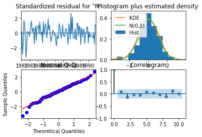

```python
plt.figure(figsize=(30,10))
results_auto_SARIMA.plot_diagnostics();
```

### Predict on the Test Set using this model and evaluate the model.

```python
predicted_auto_SARIMA = results_auto_SARIMA.get_forecast(steps=len(test))
```

```python
predicted_auto_SARIMA.summary_frame(alpha=0.05).head()
```

| Rose | mean | mean_se | mean_ci_lower | mean_ci_upper |
| --- | --- | --- | --- | --- |
| 1991-01-31 | 66.900081 | 16.350100 | 34.854473 | 98.945689 |
| 1991-02-28 | 65.989476 | 16.481270 | 33.686780 | 98.292172 |
| 1991-03-31 | 74.437493 | 16.587192 | 41.927193 | 106.947793 |
| 1991-04-30 | 76.040170 | 16.709772 | 43.289619 | 108.790721 |
| 1991-05-31 | 78.414552 | 16.710386 | 45.662797 | 111.166306 |

```python
from sklearn.metrics import mean_squared_error
```

```python
rmse = mean_squared_error(test['Rose'],predicted_auto_SARIMA.predicted_mean,squared=False)

print('RMSE:',rmse)
```

```
RMSE: 27.148086060422422
```

```python
resultsDf_10 = pd.DataFrame({'Test RMSE': [rmse]},index=['SARIMA(2,1,3)(2,0,3,6)'])


resultsDf = pd.concat([resultsDf,resultsDf_10])

resultsDf
```

|  | Test RMSE |
| --- | --- |
| RegressionOnTime | 15.275520 |
| NaiveModel | 79.738146 |
| SimpleAverageModel | 53.480456 |
| 2pointTrailingMovingAverage | 11.529720 |
| 4pointTrailingMovingAverage | 14.456379 |
| 6pointTrailingMovingAverage | 14.570846 |
| 9pointTrailingMovingAverage | 14.731252 |
| Alpha=0.995,SimpleExponentialSmoothing | 36.816502 |
| Alpha=0.3,SimpleExponentialSmoothing | 47.524854 |
| Alpha=0.3,Beta=0.3,DoubleExponentialSmoothing | 265.591576 |
| Alpha=0.111,Beta=0.0616,Gamma=0.394,TripleExponentialSmoothing | 21.046473 |
| Alpha=0.3,Beta=0.45,Gamma=0.3,TripleExponentialSmoothing | 10.950048 |
| ARIMA(3, 1, 3) | 15.994252 |
| SARIMA(2,1,3)(2,0,3,6) | 27.148086 |

## 7. Build ARIMA/SARIMA models based on the cut-off points of ACF and PACF on the training data and evaluate this model on the test data using RMSE

```python
from statsmodels.graphics.tsaplots import plot_acf, plot_pacf
```

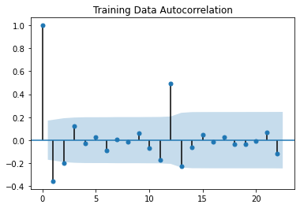

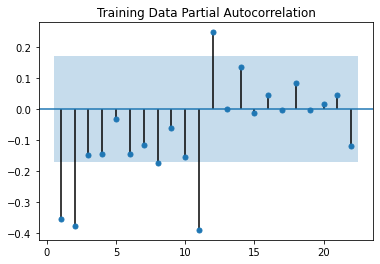

```python
plot_acf(train.diff(),title='Training Data Autocorrelation',missing='drop')
plot_pacf(train.diff().dropna(),title='Training Data Partial Autocorrelation',zero=False,method='ywmle')
plt.show()
```

Here, we have taken alpha=0.05.

```python
manual_ARIMA = ARIMA(train['Rose'], order=(3,1,3),freq='M')

results_manual_ARIMA = manual_ARIMA.fit()

print(results_manual_ARIMA.summary())
```

```
                             ARIMA Model Results
==============================================================================
Dep. Variable:                 D.Rose   No. Observations:                  131
Model:                 ARIMA(3, 1, 3)   Log Likelihood                -628.597
Method:                       css-mle   S.D. of innovations             28.356
Date:                Sat, 25 Dec 2021   AIC                           1273.194
Time:                        22:25:24   BIC                           1296.196
Sample:                    02-29-1980   HQIC                          1282.541
                         - 12-31-1990
================================================================================
                   coef    std err          z      P>|z|      [0.025      0.975]
--------------------------------------------------------------------------------
const           -0.4906      0.088     -5.548      0.000      -0.664      -0.317
ar.L1.D.Rose    -0.7243      0.086     -8.411      0.000      -0.893      -0.556
ar.L2.D.Rose    -0.7218      0.087     -8.342      0.000      -0.891      -0.552
ar.L3.D.Rose     0.2763      0.085      3.234      0.001       0.109       0.444
ma.L1.D.Rose    -0.0151      0.045     -0.339      0.735      -0.102       0.072
ma.L2.D.Rose     0.0151      0.044      0.340      0.734      -0.072       0.102
ma.L3.D.Rose    -1.0000      0.046    -21.901      0.000      -1.089      -0.911
                                    Roots
=============================================================================
                  Real          Imaginary           Modulus         Frequency
-----------------------------------------------------------------------------
AR.1           -0.5011           -0.8661j            1.0006           -0.3335
AR.2           -0.5011           +0.8661j            1.0006            0.3335
AR.3            3.6142           -0.0000j            3.6142           -0.0000
MA.1            1.0000           -0.0000j            1.0000           -0.0000
MA.2           -0.4925           -0.8703j            1.0000           -0.3320
MA.3           -0.4925           +0.8703j            1.0000            0.3320
-----------------------------------------------------------------------------
```

```python
predicted_manual_ARIMA = results_manual_ARIMA.forecast(steps=len(test))
```

```python
rmse = mean_squared_error(test['Rose'],predicted_manual_ARIMA[0],squared=False)
print(rmse)
```

```
15.994251534453136
```

```python
resultsDf_11 = pd.DataFrame({'RMSE': [rmse]}
                           ,index=['ARIMA(3,1,3)'])


resultsDf = pd.concat([resultsDf,resultsDf_11])

resultsDf
```

|  | Test RMSE | RMSE |
| --- | --- | --- |
| RegressionOnTime | 15.275520 | NaN |
| NaiveModel | 79.738146 | NaN |
| SimpleAverageModel | 53.480456 | NaN |
| 2pointTrailingMovingAverage | 11.529720 | NaN |
| 4pointTrailingMovingAverage | 14.456379 | NaN |
| 6pointTrailingMovingAverage | 14.570846 | NaN |
| 9pointTrailingMovingAverage | 14.731252 | NaN |
| Alpha=0.995,SimpleExponentialSmoothing | 36.816502 | NaN |
| Alpha=0.3,SimpleExponentialSmoothing | 47.524854 | NaN |
| Alpha=0.3,Beta=0.3,DoubleExponentialSmoothing | 265.591576 | NaN |
| Alpha=0.111,Beta=0.0616,Gamma=0.394,TripleExponentialSmoothing | 21.046473 | NaN |
| Alpha=0.3,Beta=0.45,Gamma=0.3,TripleExponentialSmoothing | 10.950048 | NaN |
| ARIMA(3, 1, 3) | 15.994252 | NaN |
| SARIMA(2,1,3)(2,0,3,6) | 27.148086 | NaN |
| ARIMA(3,1,3) | NaN | 15.994252 |

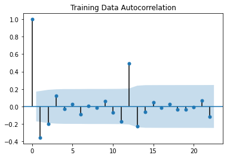

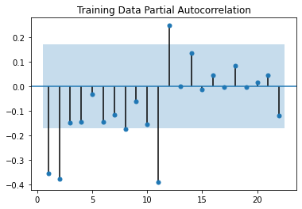

```python
plot_acf(train.diff(),title='Training Data Autocorrelation',missing='drop')
plot_pacf(train.diff().dropna(),title='Training Data Partial Autocorrelation',zero=False,method='ywmle');
```

```python
import statsmodels.api as sm

manual_SARIMA = sm.tsa.statespace.SARIMAX(train['Rose'],
                                order=(3,1,3),
                                seasonal_order=(0, 0, 0, 6),
                                enforce_stationarity=False,
                                enforce_invertibility=False)
results_manual_SARIMA = manual_SARIMA.fit(maxiter=1000)
print(results_manual_SARIMA.summary())
```

```
                               SARIMAX Results
==============================================================================
Dep. Variable:                   Rose   No. Observations:                  132
Model:               SARIMAX(3, 1, 3)   Log Likelihood                -614.869
Date:                Sat, 25 Dec 2021   AIC                           1243.739
Time:                        22:25:26   BIC                           1263.648
Sample:                    01-31-1980   HQIC                          1251.827
                         - 12-31-1990
Covariance Type:                  opg
==============================================================================
                 coef    std err          z      P>|z|      [0.025      0.975]
------------------------------------------------------------------------------
ar.L1         -1.5771      0.087    -18.067      0.000      -1.748      -1.406
ar.L2         -0.6528      0.143     -4.574      0.000      -0.933      -0.373
ar.L3          0.1257      0.091      1.383      0.167      -0.053       0.304
ma.L1          0.9505     14.216      0.067      0.947     -26.912      28.812
ma.L2         -0.7057      2.241     -0.315      0.753      -5.099       3.687
ma.L3         -0.9147     13.953     -0.066      0.948     -28.262      26.433
sigma2       878.3546   1.34e+04      0.065      0.948   -2.54e+04    2.72e+04
===================================================================================
Ljung-Box (L1) (Q):                   0.01   Jarque-Bera (JB):                22.33
Prob(Q):                              0.91   Prob(JB):                         0.00
Heteroskedasticity (H):               0.37   Skew:                             0.68
Prob(H) (two-sided):                  0.00   Kurtosis:                         4.55
===================================================================================

Warnings:
[1] Covariance matrix calculated using the outer product of gradients (complex-step).
```

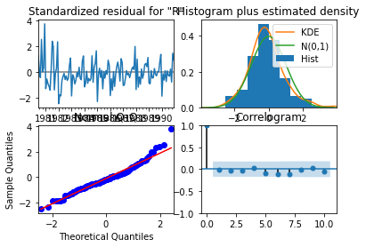

```python
results_manual_SARIMA.plot_diagnostics()
plt.show()
```

#### Predict on the Test Set using this model and evaluate the model

```python
predicted_manual_SARIMA = results_manual_SARIMA.get_forecast(steps=len(test))
```

```python
rmse = mean_squared_error(test['Rose'],predicted_manual_SARIMA.predicted_mean,squared=False)

print('RMSE:',rmse)
```

```
RMSE: 36.465055766218526
```

## 8. Build a table with all the models built along with their corresponding parameters and the respective RMSE values on the test data.

```python
resultsDf_13 = pd.DataFrame({'Test RMSE': [rmse]}
                           ,index=['SARIMA(3,1,3)(0,0,0,6)'])


resultsDf = pd.concat([resultsDf,resultsDf_13])

resultsDf
```

|  | Test RMSE | RMSE |
| --- | --- | --- |
| RegressionOnTime | 15.275520 | NaN |
| NaiveModel | 79.738146 | NaN |
| SimpleAverageModel | 53.480456 | NaN |
| 2pointTrailingMovingAverage | 11.529720 | NaN |
| 4pointTrailingMovingAverage | 14.456379 | NaN |
| 6pointTrailingMovingAverage | 14.570846 | NaN |
| 9pointTrailingMovingAverage | 14.731252 | NaN |
| Alpha=0.995,SimpleExponentialSmoothing | 36.816502 | NaN |
| Alpha=0.3,SimpleExponentialSmoothing | 47.524854 | NaN |
| Alpha=0.3,Beta=0.3,DoubleExponentialSmoothing | 265.591576 | NaN |
| Alpha=0.111,Beta=0.0616,Gamma=0.394,TripleExponentialSmoothing | 21.046473 | NaN |
| Alpha=0.3,Beta=0.45,Gamma=0.3,TripleExponentialSmoothing | 10.950048 | NaN |
| ARIMA(3, 1, 3) | 15.994252 | NaN |
| SARIMA(2,1,3)(2,0,3,6) | 27.148086 | NaN |
| ARIMA(3,1,3) | NaN | 15.994252 |
| SARIMA(3,1,3)(0,0,0,6) | 36.465056 | NaN |